# Nested Random Effects Tests

Brett Engelmann

Wednesday, July 8th, 2015

# Overview

3 “Yoruba’ individuals 2”biological" replicates per individual. That is, the same frozen stock cultured in parallel. 2 “technical” replicates per biological replicate. Technical is the multi-step mass spec protocol.

Each sample was metabolically labeled with heavy arginine and lysine. The standard is unlabeled.

## Packages Used

```r
require(nlme)
require(gplots)
require(RColorBrewer)
require(plyr)
require(reshape2)
require(qdapRegex)
```

## Data structure

The normalized and batch corrected H/L data is structured as shown here:

```r
## For each phosphopeptide, the following is fed into the model.
example <- levels(melted$Var1)[1]
test <- melted[melted$Var1 %in% example,]
str(test)
```

```
## 'data.frame':    12 obs. of  6 variables:
##  $ Var1      : Factor w/ 1463 levels "57_1","82_1",..: 1 1 1 1 1 1 1 1 1 1 ...
##  $ Var2      : Factor w/ 12 levels "HL18486_1_1",..: 1 2 3 4 5 6 7 8 9 10 ...
##  $ value     : num  -0.105 -0.2363 -0.0766 -0.0672 -0.2067 ...
##  $ individual: Factor w/ 3 levels "18486","18862",..: 1 1 1 1 2 2 2 2 3 3 ...
##  $ biorep    : Factor w/ 2 levels "1","2": 1 1 2 2 1 1 2 2 1 1 ...
##  $ techrep   : Factor w/ 2 levels "1","2": 1 2 1 2 1 2 1 2 1 2 ...
```

```r
knitr::kable(test, format = "markdown", digits = 3, row.names=F)
```

| Var1 | Var2 | value | individual | biorep | techrep |
| --- | --- | --- | --- | --- | --- |
| 57_1 | HL18486_1_1 | -0.105 | 18486 | 1 | 1 |
| 57_1 | HL18486_1_2 | -0.236 | 18486 | 1 | 2 |
| 57_1 | HL18486_2_1 | -0.077 | 18486 | 2 | 1 |
| 57_1 | HL18486_2_2 | -0.067 | 18486 | 2 | 2 |
| 57_1 | HL18862_1_1 | -0.207 | 18862 | 1 | 1 |
| 57_1 | HL18862_1_2 | -0.215 | 18862 | 1 | 2 |
| 57_1 | HL18862_2_1 | -0.073 | 18862 | 2 | 1 |
| 57_1 | HL18862_2_2 | -0.076 | 18862 | 2 | 2 |
| 57_1 | HL19160_1_1 | -0.014 | 19160 | 1 | 1 |
| 57_1 | HL19160_1_2 | 0.190 | 19160 | 1 | 2 |
| 57_1 | HL19160_2_1 | -0.112 | 19160 | 2 | 1 |
| 57_1 | HL19160_2_2 | -0.356 | 19160 | 2 | 2 |

## Model Fitting

```r
sites <- c()
  Varcomp <- c()
  Expindvar <- c()
  Expindvarmeans <- c()
  Expbiovar <- c()
  Expbiovarmeans <- c()
  Exptechvar <- c()
  for(id in levels(melted$Var1)){
    test <- melted[melted$Var1 %in% id,]
    test1 <- test[3:6]
    test1$biorep <- as.factor(test1$biorep)
    pos_err <- tryCatch(lme(value~1, data=test1, random =~1|individual/biorep, na.action = na.exclude),error=function(e) e)
    if(!inherits(pos_err, "error")){
      lmemodel <- lme(value~1, data=test1, random =~1|individual/biorep, na.action = na.exclude)
      temp <- as.numeric(VarCorr(lmemodel)[,1])
      temp <- temp[!is.na(temp)]
      temp <- na.omit(temp)
      Expindvartmp <- 4*temp[1]+2*temp[2]+temp[3]
      Expindvar <- c(Expindvar,Expindvartmp)
      Expindvarmeanstmp <- Expindvartmp/4
      Expindvarmeans <- c(Expindvarmeans,Expindvarmeanstmp)
      Expbiovartmp <- 2*temp[2]+temp[3]
      Expbiovar <- c(Expbiovar,Expbiovartmp)
      Expbiovarmeanstmp <- Expbiovartmp/2
      Expbiovarmeans <- c(Expbiovarmeans,Expbiovarmeanstmp)
      Exptechvartmp <- temp[3]
      Exptechvar <- c(Exptechvar,Exptechvartmp)
      Varcomp <- cbind(Varcomp,temp)
      sites <- c(sites,as.character(unique(test$Var1)))
    }
  }
```

# Variance Component Sturcture

Overall, variation due to individual samples is larger than variation due to technical noise, followed by variation due to biological replicates.

```r
#Define the DF
colnames(Varcomp) <- sites
row.names(Varcomp) <- c("individual","biorep","residual")
dim(Varcomp)
```

```
## [1]    3 1462
```

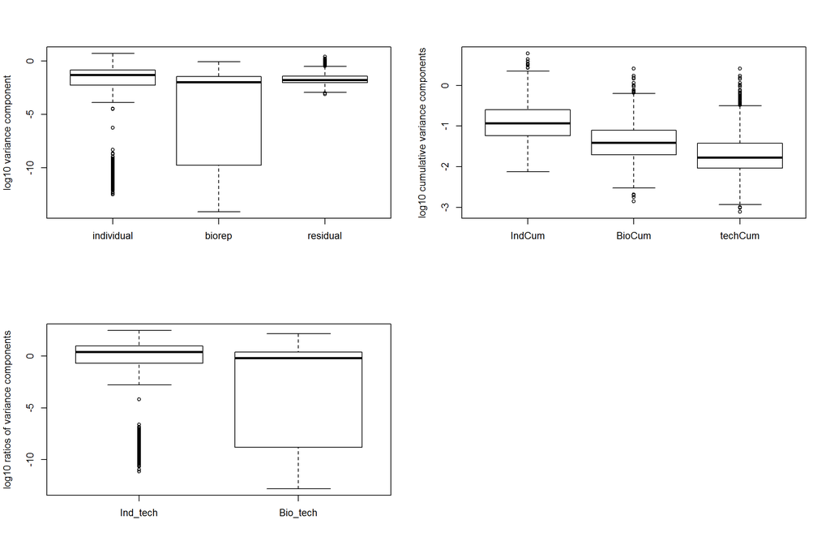

```r
Varcomp <- t(Varcomp)

##cumulative Varcomp
Varcomp2 <- Varcomp
IndCum <- rowSums(Varcomp2)
Varcomp2[,1] <- 0
BioCum <- rowSums(Varcomp2)
Varcomp2[,2] <- 0
techCum <- rowSums(Varcomp2) #for symmetry!
CumMat <- cbind(IndCum,BioCum,techCum)

##Ratio of component estimates relative to technical
Ind_tech <- Varcomp[,1]/Varcomp[,3]
Bio_tech <- Varcomp[,2]/Varcomp[,3]
ratios_tech <- cbind(Ind_tech,Bio_tech)

#plot the variance component distributions
par(mfrow = c(2,2))
boxplot(log10(Varcomp), ylab = "log10 variance component")
boxplot(log10(CumMat), ylab = "log10 cumulative variance components")
boxplot(log10(ratios_tech), ylab = "log10 ratios of variance components")
```

Both individual and biological VCs follow a bi modal distribution. A significant number of the phosphopeptides have very small individual VC and biological VC. Technical VC are uni modal.

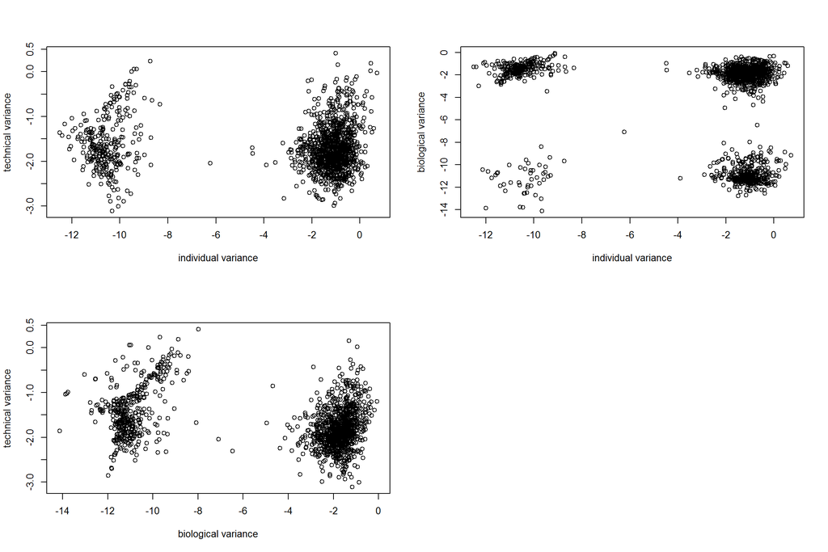

```r
##scatter plots show discrete groupings?
par(mfrow = c(2,2))
plot(log10(Varcomp[,1]),log10(Varcomp[,3]), xlab = "individual variance", ylab = "technical variance")
plot(log10(Varcomp[,1]),log10(Varcomp[,2]), xlab = "individual variance", ylab = "biological variance")
plot(log10(Varcomp[,2]),log10(Varcomp[,3]), xlab = "biological variance", ylab = "technical variance")
par(mfrow = c(1,1))
```

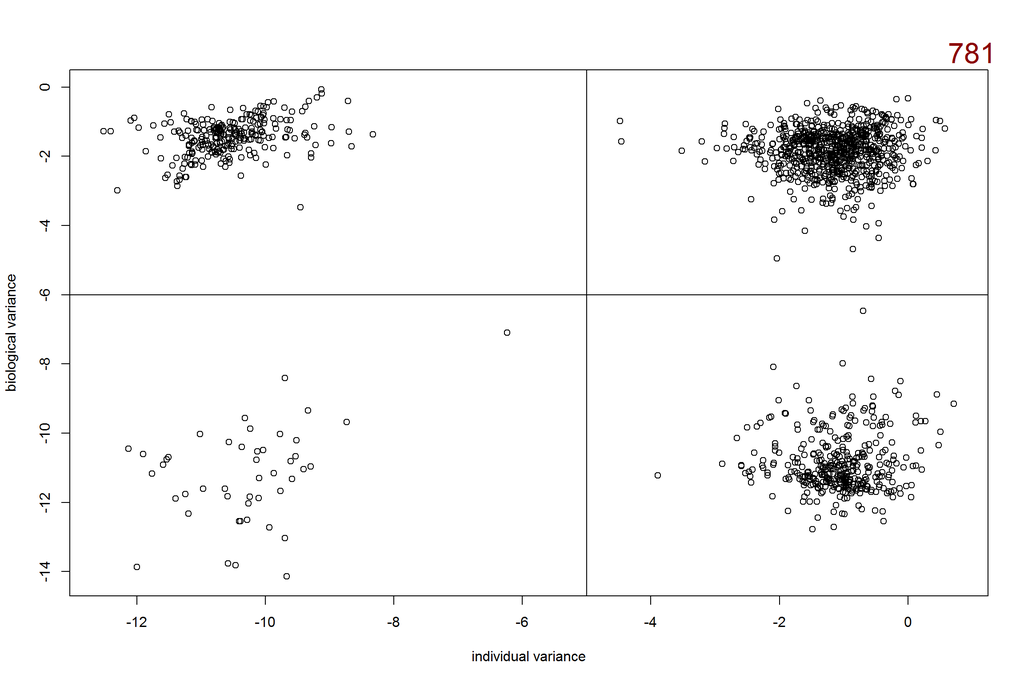

```r
#scatterplot of individual and biological variance with numbers overlaid
high_ind_var <- ifelse(log10(Varcomp[,1]) >= -5, "+", "-")
low_ind_var <- ifelse(log10(Varcomp[,1]) < -5, "+", "-")
high_bio_var <- ifelse(log10(Varcomp[,2]) >= -6, "+", "-")
low_bio_var <- ifelse(log10(Varcomp[,2]) < -6, "+", "-")
plot(log10(Varcomp[,1]),log10(Varcomp[,2]), xlab = "individual variance", ylab = "biological variance")
abline(v = -5)
abline(h = -6)
text(1, 1, sum(high_ind_var == "+" & high_bio_var == "+"), col = "darkred", cex = 2, xpd = T)
text(0,-15, sum(low_bio_var == "+" & high_ind_var == "+"), col = "darkred",cex = 2)
text(-15,0, sum(high_bio_var == "+" & low_ind_var == "+"), col = "darkred",cex = 2)
text(-15,-15, sum(low_bio_var == "+" & low_ind_var == "+"), col = "darkred",cex = 2)
```

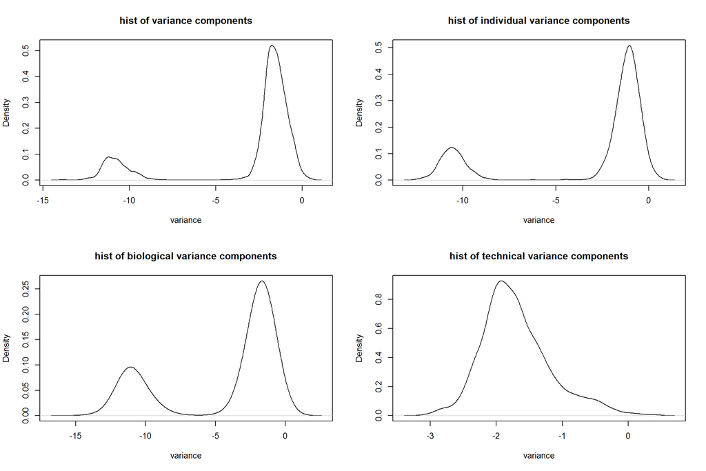

```r
#histograms of log10 variance are bimodal for biological and individual variance.
# plot.new()
par(mfrow = c(2,2))
plot(density(log10(Varcomp)), xlab = "variance", main = "hist of variance components")
plot(density(log10(Varcomp[,1])), xlab = "variance", main = "hist of individual variance components")
plot(density(log10(Varcomp[,2])), xlab = "variance", main = "hist of biological variance components")
plot(density(log10(Varcomp[,3])), xlab = "variance", main = "hist of technical variance components")
```

The overall variability per peptide is unimodal.

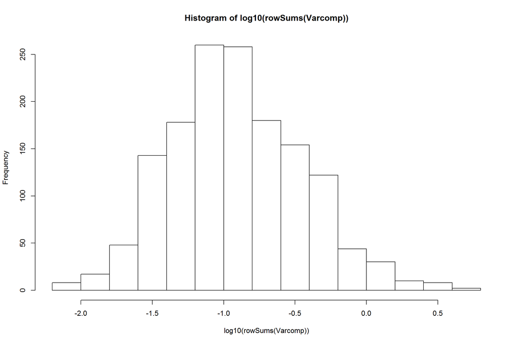

```r
  hist(log10(rowSums(Varcomp)))
```

Greater total phosphopeptide variability may result in a disproportionate distribution of extremely small estimates of bio/ind variance model terms. This does not seem to be the case here as the low bio/tech VC estimates are distributed across the entire range of total variance.

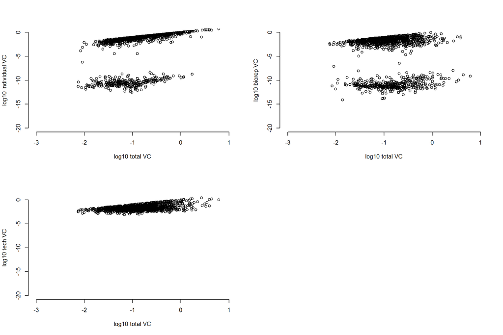

```r
par(mfrow=c(2,2))
ylims=c(-20,0);xlims=c(-3,1)
plot(log10(rowSums(Varcomp)),log10(Varcomp[,1]),xlim=xlims,ylim=ylims,
     xlab="log10 total VC",ylab="log10 individual VC",axes=F)
axis(1);axis(2)
plot(log10(rowSums(Varcomp)),log10(Varcomp[,2]),xlim=xlims,ylim=ylims,
     xlab="log10 total VC",ylab="log10 biorep VC",axes=F)
axis(1);axis(2)
plot(log10(rowSums(Varcomp)),log10(Varcomp[,3]),xlim=xlims,ylim=ylims,
     xlab="log10 total VC",ylab="log10 tech VC",axes=F)
axis(1);axis(2)
```

Box plots of the standardized VCs confirm the observations from the raw VC values. Proportion of variability attributed to biological replicates is the smallest, followed by technical replicates, with individual samples contributing the largest portion of variability in expression levels.

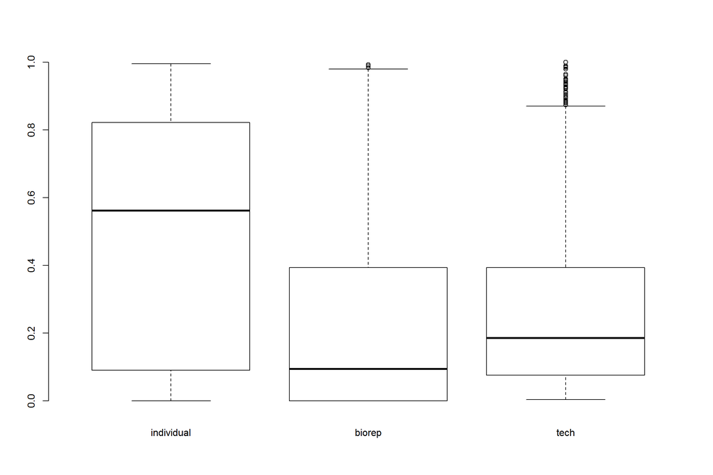

```r
par(mfrow = c(1,1))
varprop = Varcomp/rowSums(Varcomp)

labs = c("individual","biorep","tech")
boxplot((varprop),axes=F)
axis(1,at=c(1,2,3),labels=labs,col="white");axis(2)
```

# ANOVA based Variance component estimates

In an attempt to get a sense of what is driving this huge partition between VarComp modes I have used an alternative variance component estimation approach. An alternative approach for balanced data is a nested ANOVA with error strata and ‘method of moments’ to estimate variance components. See ST1 in this link for an example: http://www.nature.com/nmeth/journal/v11/n10/full/nmeth.3137.html

Here negative Variance components are possible when The mean square of the nested level is greater than the mean square of the parent level. This explains why the ‘residual’ variance component distribution is unimodal (there is nothing nested below it). After fitting using this process and removing all negative variance components the overall signature of the data is consistent with the REML estimates but **all of the low values from REML estimates are gone**. That is, all of the low REML estimates are all negative estimates in the ANOVA based approach.

On a first glance Joyce assures me this all is fine and perhaps it is. However if all of the smaller variance component estimates are due to the relative noise levels in the design, **I still stongly suspect a fitting artifact**. For instance, why are **all** of the negative variance components found in the lower modes of the individual and biological VC distributions? (see below) Isn’t it likely that a few of the biolgical variance components are only slightly greater than the individual variance components? Keep in mind we are talking about many OOM differences between the central tendencies of the modes, so these are huge differences.

```r
#all 'balanced' data run with this variance component estimation approach. Note there are some negative estimates
sites <- c()
IndVarComp <- c()
BioVarComp <- c()
TechVarComp <- c()

for(id in levels(melted$Var1)){
  test <- melted[melted$Var1 %in% id,]
  test1 <- test[3:6]
  pos_err <- tryCatch(aov(value ~ individual/biorep/techrep, data=test1),error=function(e) e)
  if(!inherits(pos_err, "error")){
    linear <- aov(value ~ individual/biorep/techrep, data=test1)
    linear <- summary(linear)
    IndVarComptmp <- (linear[[1]][1,3] - linear[[1]][2,3])/4
    BioVarComptmp <- (linear[[1]][2,3] - linear[[1]][3,3])/2
    TechVarComptmp <- linear[[1]][3,3]
    IndVarComp <- c(IndVarComp, IndVarComptmp)
    BioVarComp <- c(BioVarComp, BioVarComptmp)
    TechVarComp <- c(TechVarComp, TechVarComptmp)
    sites <- c(sites,as.character(unique(test$Var1)))
  }
}
```

Scatter plots no longer show discrete groupings. quadrant plot is no longer present

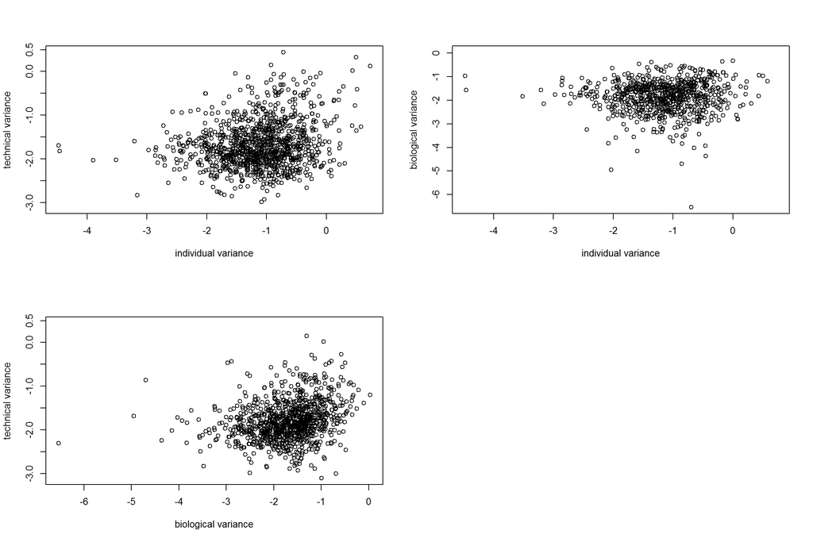

```r
mmVarcomp <- cbind(IndVarComp,BioVarComp,TechVarComp)
row.names(mmVarcomp) <- sites
par(mfrow = c(2,2))
plot(log10(mmVarcomp[,1]),log10(mmVarcomp[,3]), xlab = "individual variance", ylab = "technical variance")
plot(log10(mmVarcomp[,1]),log10(mmVarcomp[,2]), xlab = "individual variance", ylab = "biological variance")
plot(log10(mmVarcomp[,2]),log10(mmVarcomp[,3]), xlab = "biological variance", ylab = "technical variance")
```

The distributions fitted via this ANOVA approach match the nested random effet model fits sans the ind/bio components with very low values

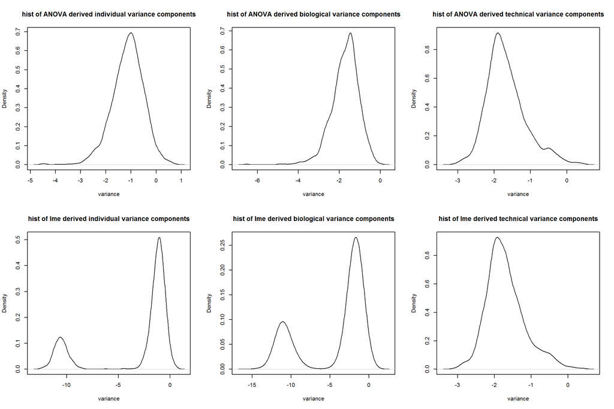

```r
par(mfrow = c(2,3))
plot(density(log10(mmVarcomp[,1]), na.rm = T), xlab = "variance", main = "hist of ANOVA derived individual variance components")
plot(density(log10(mmVarcomp[,2]), na.rm = T), xlab = "variance", main = "hist of ANOVA derived biological variance components")
plot(density(log10(mmVarcomp[,3]), na.rm = T), xlab = "variance", main = "hist of ANOVA derived technical variance components")
plot(density(log10(Varcomp[,1])), xlab = "variance", main = "hist of lme derived individual variance components")
plot(density(log10(Varcomp[,2])), xlab = "variance", main = "hist of lme derived biological variance components")
plot(density(log10(Varcomp[,3])), xlab = "variance", main = "hist of lme derived technical variance components")
```

Overlap of linear model and nested model

```r
#ind/bio var categorization by REML estimation (lme)
Varcomp2 <- as.data.frame(Varcomp)
Varcomp2$high_ind_var <- ifelse(log10(Varcomp[,1]) >= -5, "TRUE", "FALSE")
Varcomp2$low_ind_var <- ifelse(log10(Varcomp[,1]) < -5, "TRUE", "FALSE")
Varcomp2$high_bio_var <- ifelse(log10(Varcomp[,2]) >= -6, "TRUE", "FALSE")
Varcomp2$low_bio_var <- ifelse(log10(Varcomp[,2]) < -6, "TRUE", "FALSE")

#fnd the low variance sites
RMLELowIndVar <- row.names(Varcomp2[Varcomp2$low_ind_var == "TRUE",])
RMLELowBioVar <- row.names(Varcomp2[Varcomp2$low_bio_var == "TRUE",])
#either
RMLELowVar <- c(RMLELowIndVar,RMLELowBioVar)
RMLELowVar <- unique(RMLELowVar)#681

#what are the zero variance sits by ANOVA method of moments?
tmp <- log10(mmVarcomp)
zeros <- tmp[rowSums(is.na(tmp[ , 1:3])) >= 1,]
zeros <- row.names(zeros)

#how many of these zeros are in the RMLE low variance category?
length(intersect(zeros,RMLELowVar))
```

```
## [1] 680
```

```r
length(zeros)
```

```
## [1] 681
```

```r
#ALL of them!! the only one missing was because the estimate did not converge for this site in lme
```

# Tests for sources of bias

The variance component signature is curious. A few questions:

- Why would the distributions be bi-modal?
- Why would there be such a lengthy valley between the two modes?
- Why would there be symmetry (in terms of the magnitude of the valley) between the modes of both of the variance components?

## Processing choices

I have tested what is shown below. All **still** reproduce the “four corners” and/or bi-modal individual variance plot.

1. Complete cases (no NAs, this was run above)
2. No normalization/Batch correction (of any sort)
   - Raw data (only MQ intensity normalization)

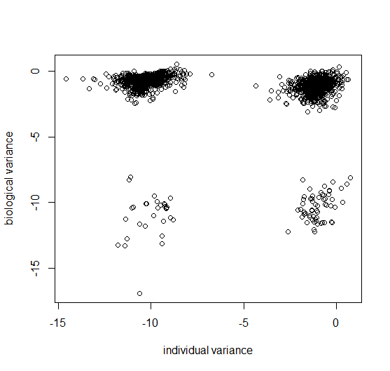

   - Single batches of raw data (Here only a random individual parameter is fitted. Batch1 and 2 show bi-modal individual varcomps)

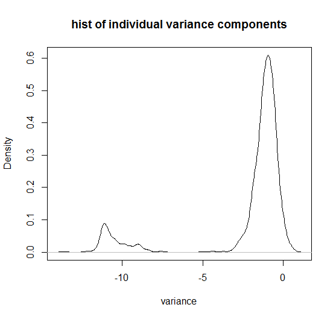

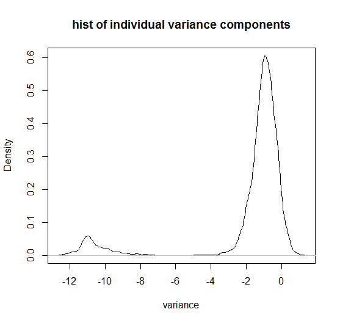

```
- Radically Raw data (Not even MQ intensity normalization)
```

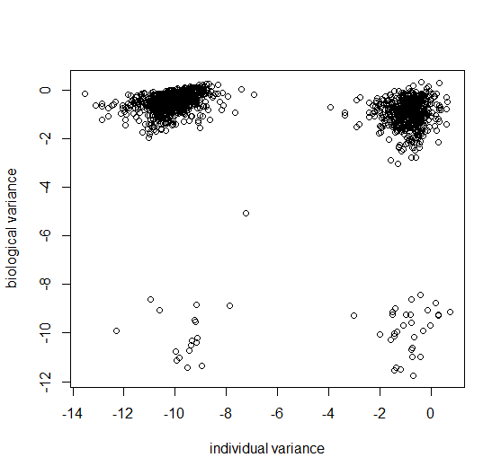

```
- Single batches of Radically Raw data
```

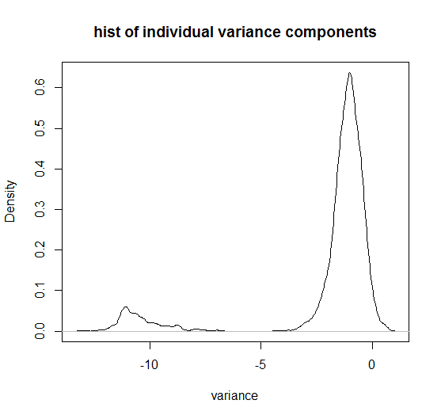

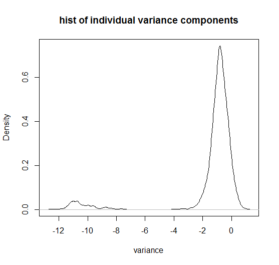

3. MS relevant and acquisition choices
   - Phosphopeptide multiplicity
     - singly phosphorylated peptides still produce signature

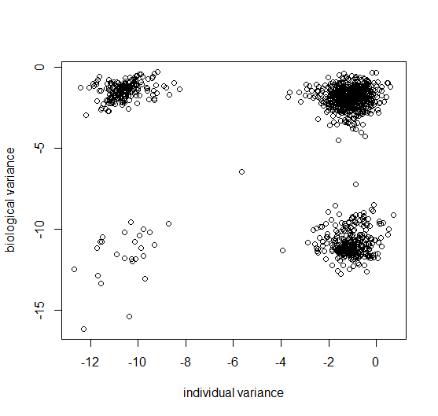

   - SILAC pairs identified without ‘re-quantify’ option

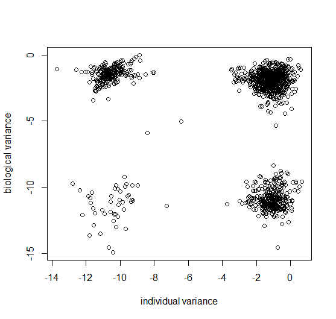

   - Ratios estimated solely from MS acquisition and not match-between-runs (MBR) feature

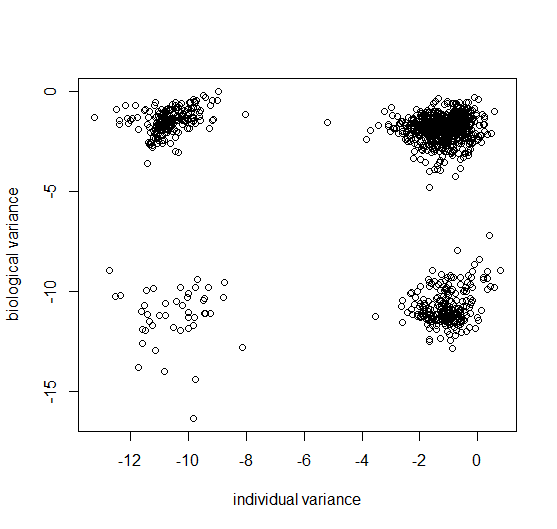

## Experimental or biological

These do **not** present a clear signature in the data

1. Hyp: Variation in labeling efficiency across samples responsible for bimodal ‘biological’ VC dist?
   - If relative labeling efficiency were contributing to this signature proteins would tend to segregate into one of the two modes. The opposite is true

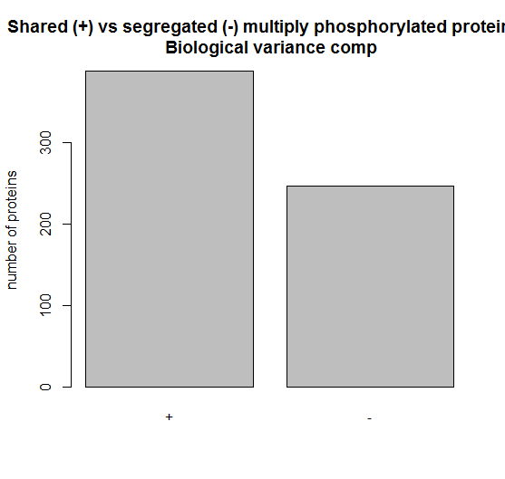

2. Protein expression level
   - Protein copynumber relatively equally distributed across clusters (result holds with protein levele estimates from phosprep)

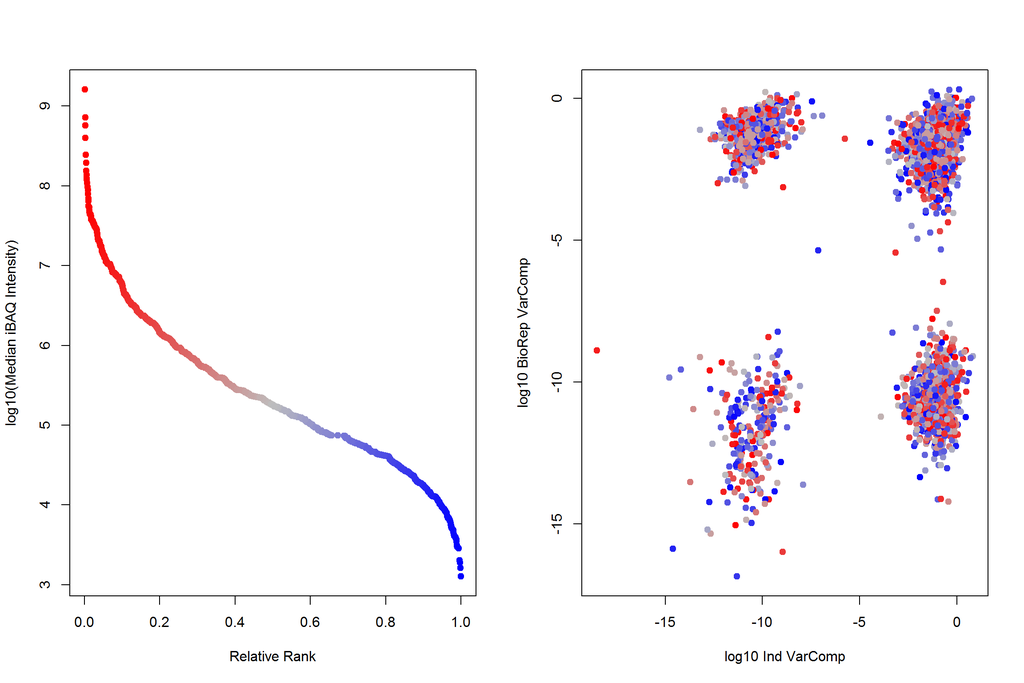

3. Phosphopeptide Intensity. Here there is an enrichment for lower intensity peptides in the low bio/low ind category. This makes sense because for these low intensity (noisy) peptides there is a greater likelihood of tech variation>bio variation>ind variation.

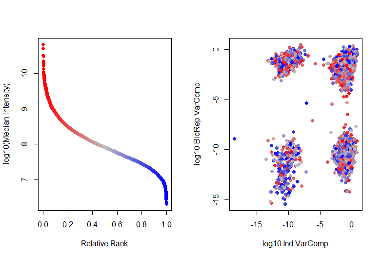

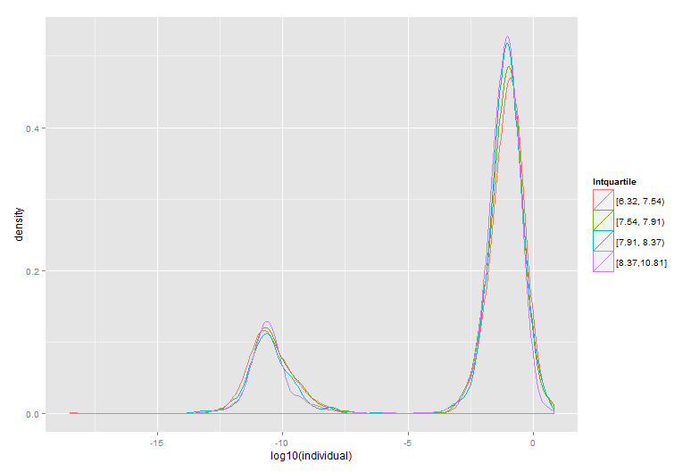

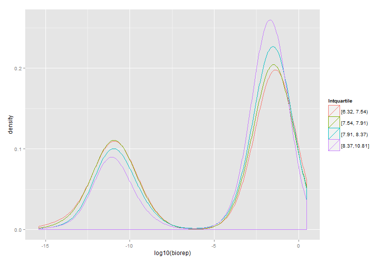

4. H/L Ratio and Magnitude of Ratio show no enrichment. (this is related to technical remove ‘requantify’ above)

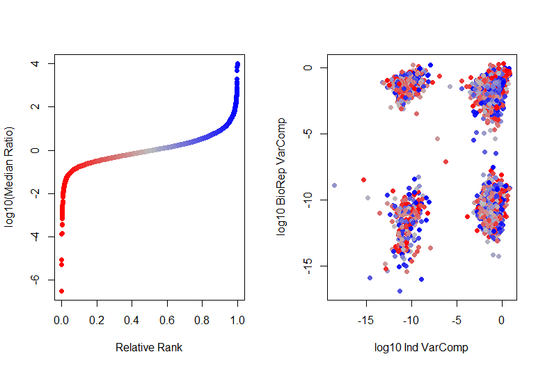

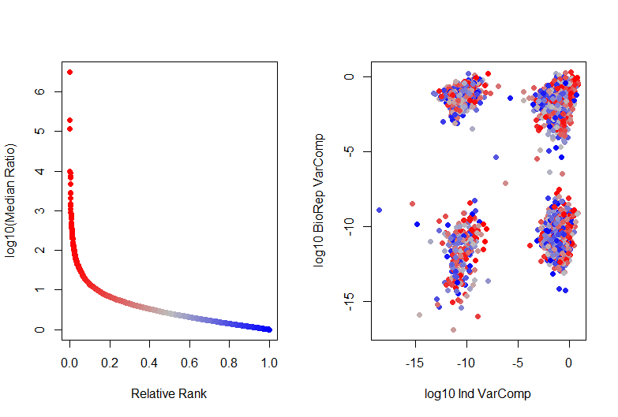

5. Protein ratios also produce the quadrant signature (just trust me).

Again I strongly suspect a problem with the REML estimates for the ANOVA negative variance components